# Third occipital nerve (TON) topology near the C2/C3 facet joint and the TON-notch

# Descriptive statistics

## Missing values

Are these values really missing? How to interpret a missing value? If we do a regression analysis, do we impute missing values?

```
## # A tidytable: 5 × 7
##   ID    side  ton_crossing         angle_crossing   distance_joint              deg_lipping     ton_notch
##   <fct> <fct> <fct>                <fct>            <fct>                       <fct>           <fct>
## 1 8     Left  underneath the joint Stump (<10°)     With adipose tissue between Slightly prese… <NA>
## 2 25    Left  Dorsal               Medium (25°-45°) With adipose tissue between Slightly prese… <NA>
## 3 70    Left  <NA>                 <NA>             <NA>                        <NA>            <NA>
## 4 74    Left  <NA>                 <NA>             <NA>                        <NA>            <NA>
## 5 64    Right Lateral              Sharp (>45°)     Close in contact            <NA>            Slightly…
```

## Univariate

### Table: characteristics of the specimens

No specimen characteristics included in recent dataset (sex, age, fresh specimen).

### Table: characteristics of the observations (L/R)

| **Characteristic** | **Overall**, N = 58<sup>1</sup> | **Left**, N = 29<sup>1</sup> | **Right**, N = 29<sup>1</sup> |
| --- | --- | --- | --- |
| ton_crossing |  |  |  |
| Lateral | 14 (25%) | 5 (19%) | 9 (31%) |
| Laterodorsal | 21 (38%) | 11 (41%) | 10 (34%) |
| Dorsal | 13 (23%) | 7 (26%) | 6 (21%) |
| underneath the joint | 8 (14%) | 4 (15%) | 4 (14%) |
| Unknown | 2 | 2 | 0 |
| angle_crossing |  |  |  |
| Stump (<10°) | 7 (13%) | 5 (19%) | 2 (6.9%) |
| Small (10°-25°) | 7 (13%) | 3 (11%) | 4 (14%) |
| Medium (25°-45°) | 23 (41%) | 10 (37%) | 13 (45%) |
| Sharp (>45°) | 19 (34%) | 9 (33%) | 10 (34%) |
| Unknown | 2 | 2 | 0 |
| distance_joint |  |  |  |
| Close in contact | 30 (54%) | 12 (44%) | 18 (62%) |
| With adipose tissue between | 26 (46%) | 15 (56%) | 11 (38%) |
| Unknown | 2 | 2 | 0 |
| deg_lipping |  |  |  |
| Not present | 22 (40%) | 13 (48%) | 9 (32%) |
| Slightly present | 24 (44%) | 11 (41%) | 13 (46%) |
| Clearly present | 9 (16%) | 3 (11%) | 6 (21%) |
| Unknown | 3 | 2 | 1 |
| ton_notch |  |  |  |
| Not present | 32 (59%) | 15 (60%) | 17 (59%) |
| Slightly present (+-1mm) | 19 (35%) | 9 (36%) | 10 (34%) |
| Clearly present (>1mm) | 3 (5.6%) | 1 (4.0%) | 2 (6.9%) |
| Unknown | 4 | 4 | 0 |

<sup>1</sup> n (%)

## Multivariate

### Table: characteristics of the observations by the level of joint degeneration

| **Characteristic** | **Overall**, N = 55<sup>1</sup> | **Not present**, N = 22<sup>1</sup> | **Slightly present**, N = 24<sup>1</sup> | **Clearly present**, N = 9<sup>1</sup> | **p-value**<sup>2</sup> |
| --- | --- | --- | --- | --- | --- |
| ton_crossing |  |  |  |  | 0.6 |
| Lateral | 13 (24%) | 5 (23%) | 4 (17%) | 4 (44%) |  |
| Laterodorsal | 21 (38%) | 9 (41%) | 10 (42%) | 2 (22%) |  |
| Dorsal | 13 (24%) | 6 (27%) | 6 (25%) | 1 (11%) |  |
| underneath the joint | 8 (15%) | 2 (9.1%) | 4 (17%) | 2 (22%) |  |
| angle_crossing |  |  |  |  | 0.8 |
| Stump (<10°) | 7 (13%) | 3 (14%) | 3 (13%) | 1 (11%) |  |
| Small (10°-25°) | 7 (13%) | 3 (14%) | 2 (8.3%) | 2 (22%) |  |
| Medium (25°-45°) | 23 (42%) | 10 (45%) | 11 (46%) | 2 (22%) |  |
| Sharp (>45°) | 18 (33%) | 6 (27%) | 8 (33%) | 4 (44%) |  |
| distance_joint |  |  |  |  | 0.7 |
| Close in contact | 29 (53%) | 10 (45%) | 14 (58%) | 5 (56%) |  |
| With adipose tissue between | 26 (47%) | 12 (55%) | 10 (42%) | 4 (44%) |  |
| ton_notch |  |  |  |  | <0.001 |
| Not present | 32 (60%) | 19 (86%) | 10 (45%) | 3 (33%) |  |
| Slightly present (+-1mm) | 18 (34%) | 3 (14%) | 12 (55%) | 3 (33%) |  |
| Clearly present (>1mm) | 3 (5.7%) | 0 (0%) | 0 (0%) | 3 (33%) |  |
| Unknown | 2 | 0 | 2 | 0 |  |

<sup>1</sup> n (%)  
<sup>2</sup> Fisher’s exact test

Hypothesis: more degeneration = more chance of notch? Fisher’s exact test points to a positive relation between level of degeneration and TON notch (p < 0.001).

Hypothesis: The bigger the degeneration, the bigger the notch? Data pointing in that direction yes, but need to think about how to test it (exclude those without notch?) Few observations with clearly present degeneration (N=9).

### Table: characteristics of the observations by location of crossing of the TON

| **Characteristic** | **Overall**, N = 56<sup>1</sup> | **Lateral**, N = 14<sup>1</sup> | **Laterodorsal**, N = 21<sup>1</sup> | **Dorsal**, N = 13<sup>1</sup> | **underneath the joint**, N = 8<sup>1</sup> | **p-value**<sup>2</sup> |
| --- | --- | --- | --- | --- | --- | --- |
| angle_crossing |  |  |  |  |  | <0.001 |
| Stump (<10°) | 7 (13%) | 0 (0%) | 0 (0%) | 2 (15%) | 5 (63%) |  |
| Small (10°-25°) | 7 (13%) | 1 (7.1%) | 0 (0%) | 3 (23%) | 3 (38%) |  |
| Medium (25°-45°) | 23 (41%) | 2 (14%) | 15 (71%) | 6 (46%) | 0 (0%) |  |
| Sharp (>45°) | 19 (34%) | 11 (79%) | 6 (29%) | 2 (15%) | 0 (0%) |  |
| distance_joint |  |  |  |  |  | <0.001 |
| Close in contact | 30 (54%) | 14 (100%) | 12 (57%) | 4 (31%) | 0 (0%) |  |
| With adipose tissue between | 26 (46%) | 0 (0%) | 9 (43%) | 9 (69%) | 8 (100%) |  |
| deg_lipping |  |  |  |  |  | 0.6 |
| Not present | 22 (40%) | 5 (38%) | 9 (43%) | 6 (46%) | 2 (25%) |  |
| Slightly present | 24 (44%) | 4 (31%) | 10 (48%) | 6 (46%) | 4 (50%) |  |
| Clearly present | 9 (16%) | 4 (31%) | 2 (9.5%) | 1 (7.7%) | 2 (25%) |  |
| Unknown | 1 | 1 | 0 | 0 | 0 |  |
| ton_notch |  |  |  |  |  | 0.003 |
| Not present | 32 (59%) | 3 (21%) | 12 (57%) | 10 (83%) | 7 (100%) |  |
| Slightly present (+-1mm) | 19 (35%) | 10 (71%) | 7 (33%) | 2 (17%) | 0 (0%) |  |
| Clearly present (>1mm) | 3 (5.6%) | 1 (7.1%) | 2 (9.5%) | 0 (0%) | 0 (0%) |  |
| Unknown | 2 | 0 | 0 | 1 | 1 |  |

<sup>1</sup> n (%)  
<sup>2</sup> Fisher’s exact test

Hypothesis: The more the crossing is dorsal = less sharp crossing? Fisher’s exact test points to a relation between dorsal crossing and angle (p < 0.001). Further tests: comparing lateral vs. dorsal only (excluding the laterodorsal and underneath).

Hypothesis: More lateral = sharper? = more chance of notch? Fisher’s exact test points to a relation between lateral crossing and notch (p = 0.003). Further tests: comparing lateral vs. dorsal only (excluding the laterodorsal and underneath).

### Table: characteristics of the observations by notch of the TON

| **Characteristic** | **Overall**, N = 54<sup>1</sup> | **Not present**, N = 32<sup>1</sup> | **Slightly present (+-1mm)**, N = 19<sup>1</sup> | **Clearly present (>1mm)**, N = 3<sup>1</sup> | **p-value**<sup>2</sup> |
| --- | --- | --- | --- | --- | --- |
| ton_crossing |  |  |  |  | 0.003 |
| Lateral | 14 (26%) | 3 (9.4%) | 10 (53%) | 1 (33%) |  |
| Laterodorsal | 21 (39%) | 12 (38%) | 7 (37%) | 2 (67%) |  |
| Dorsal | 12 (22%) | 10 (31%) | 2 (11%) | 0 (0%) |  |
| underneath the joint | 7 (13%) | 7 (22%) | 0 (0%) | 0 (0%) |  |
| angle_crossing |  |  |  |  | 0.001 |
| Stump (<10°) | 6 (11%) | 6 (19%) | 0 (0%) | 0 (0%) |  |
| Small (10°-25°) | 7 (13%) | 7 (22%) | 0 (0%) | 0 (0%) |  |
| Medium (25°-45°) | 22 (41%) | 14 (44%) | 6 (32%) | 2 (67%) |  |
| Sharp (>45°) | 19 (35%) | 5 (16%) | 13 (68%) | 1 (33%) |  |
| distance_joint |  |  |  |  | <0.001 |
| Close in contact | 30 (56%) | 11 (34%) | 17 (89%) | 2 (67%) |  |
| With adipose tissue between | 24 (44%) | 21 (66%) | 2 (11%) | 1 (33%) |  |
| deg_lipping |  |  |  |  | <0.001 |
| Not present | 22 (42%) | 19 (59%) | 3 (17%) | 0 (0%) |  |
| Slightly present | 22 (42%) | 10 (31%) | 12 (67%) | 0 (0%) |  |
| Clearly present | 9 (17%) | 3 (9.4%) | 3 (17%) | 3 (100%) |  |
| Unknown | 1 | 0 | 1 | 0 |  |

<sup>1</sup> n (%)  
<sup>2</sup> Fisher’s exact test

### Table: characteristics of the observations by the angle of crossing

| **Characteristic** | **Overall**, N = 56<sup>1</sup> | **Stump (<10°)**, N = 7<sup>1</sup> | **Small (10°-25°)**, N = 7<sup>1</sup> | **Medium (25°-45°)**, N = 23<sup>1</sup> | **Sharp (>45°)**, N = 19<sup>1</sup> | **p-value**<sup>2</sup> |
| --- | --- | --- | --- | --- | --- | --- |
| ton_crossing |  |  |  |  |  | <0.001 |
| Lateral | 14 (25%) | 0 (0%) | 1 (14%) | 2 (8.7%) | 11 (58%) |  |
| Laterodorsal | 21 (38%) | 0 (0%) | 0 (0%) | 15 (65%) | 6 (32%) |  |
| Dorsal | 13 (23%) | 2 (29%) | 3 (43%) | 6 (26%) | 2 (11%) |  |
| underneath the joint | 8 (14%) | 5 (71%) | 3 (43%) | 0 (0%) | 0 (0%) |  |
| distance_joint |  |  |  |  |  | <0.001 |
| Close in contact | 30 (54%) | 0 (0%) | 2 (29%) | 12 (52%) | 16 (84%) |  |
| With adipose tissue between | 26 (46%) | 7 (100%) | 5 (71%) | 11 (48%) | 3 (16%) |  |
| deg_lipping |  |  |  |  |  | 0.8 |
| Not present | 22 (40%) | 3 (43%) | 3 (43%) | 10 (43%) | 6 (33%) |  |
| Slightly present | 24 (44%) | 3 (43%) | 2 (29%) | 11 (48%) | 8 (44%) |  |
| Clearly present | 9 (16%) | 1 (14%) | 2 (29%) | 2 (8.7%) | 4 (22%) |  |
| Unknown | 1 | 0 | 0 | 0 | 1 |  |
| ton_notch |  |  |  |  |  | 0.001 |
| Not present | 32 (59%) | 6 (100%) | 7 (100%) | 14 (64%) | 5 (26%) |  |
| Slightly present (+-1mm) | 19 (35%) | 0 (0%) | 0 (0%) | 6 (27%) | 13 (68%) |  |
| Clearly present (>1mm) | 3 (5.6%) | 0 (0%) | 0 (0%) | 2 (9.1%) | 1 (5.3%) |  |
| Unknown | 2 | 1 | 0 | 1 | 0 |  |

<sup>1</sup> n (%)  
<sup>2</sup> Fisher’s exact test

### Table: characteristics of the observations by the distance to the joint

| **Characteristic** | **Overall**, N = 56<sup>1</sup> | **Close in contact**, N = 30<sup>1</sup> | **With adipose tissue between**, N = 26<sup>1</sup> | **p-value**<sup>2</sup> |
| --- | --- | --- | --- | --- |
| ton_crossing |  |  |  | <0.001 |
| Lateral | 14 (25%) | 14 (47%) | 0 (0%) |  |
| Laterodorsal | 21 (38%) | 12 (40%) | 9 (35%) |  |
| Dorsal | 13 (23%) | 4 (13%) | 9 (35%) |  |
| underneath the joint | 8 (14%) | 0 (0%) | 8 (31%) |  |
| angle_crossing |  |  |  | <0.001 |
| Stump (<10°) | 7 (13%) | 0 (0%) | 7 (27%) |  |
| Small (10°-25°) | 7 (13%) | 2 (6.7%) | 5 (19%) |  |
| Medium (25°-45°) | 23 (41%) | 12 (40%) | 11 (42%) |  |
| Sharp (>45°) | 19 (34%) | 16 (53%) | 3 (12%) |  |
| deg_lipping |  |  |  | 0.7 |
| Not present | 22 (40%) | 10 (34%) | 12 (46%) |  |
| Slightly present | 24 (44%) | 14 (48%) | 10 (38%) |  |
| Clearly present | 9 (16%) | 5 (17%) | 4 (15%) |  |
| Unknown | 1 | 1 | 0 |  |
| ton_notch |  |  |  | <0.001 |
| Not present | 32 (59%) | 11 (37%) | 21 (88%) |  |
| Slightly present (+-1mm) | 19 (35%) | 17 (57%) | 2 (8.3%) |  |
| Clearly present (>1mm) | 3 (5.6%) | 2 (6.7%) | 1 (4.2%) |  |
| Unknown | 2 | 0 | 2 |  |

<sup>1</sup> n (%)  
<sup>2</sup> Fisher’s exact test

### Tables: (a)symmetries between L & R observations

There is quite some symmetry between left and right TON observations. Only angle_crossing and deg_lipping have <50% symmetries. The reason I checked symmetry is that we should not treat each side as an independent observation if we do a statistical analysis. Both sides are clustered within the same cadaver and this should be accounted for. To be decided how exactly; mixed model or GEE.

| **Characteristic** | **Symmetric** N = 17 (71%)<sup>1</sup> | **Asymmetric** N = 7 (29%)<sup>1</sup> |
| --- | --- | --- |
| combo.ton_crossing |  |  |
| Dorsal | 4 (24%) | 0 (0%) |
| Dorsal & Lateral | 0 (0%) | 1 (14%) |
| Dorsal & Laterodorsal | 0 (0%) | 2 (29%) |
| Lateral | 5 (29%) | 0 (0%) |
| Laterodorsal | 6 (35%) | 0 (0%) |
| Laterodorsal & Lateral | 0 (0%) | 2 (29%) |
| underneath the joint | 2 (12%) | 0 (0%) |
| underneath the joint & Laterodorsal | 0 (0%) | 2 (29%) |

<sup>1</sup> n (%)

| **Characteristic** | **Symmetric** N = 15 (63%)<sup>1</sup> | **Asymmetric** N = 9 (38%)<sup>1</sup> |
| --- | --- | --- |
| combo.ton_notch |  |  |
| Clearly present (>1mm) & Slightly present (+-1mm) | 0 (0%) | 3 (33%) |
| Not present | 11 (73%) | 0 (0%) |
| Slightly present (+-1mm) | 4 (27%) | 0 (0%) |
| Slightly present (+-1mm) & Not present | 0 (0%) | 6 (67%) |

<sup>1</sup> n (%)

| **Characteristic** | **Symmetric** N = 11 (46%)<sup>1</sup> | **Asymmetric** N = 13 (54%)<sup>1</sup> |
| --- | --- | --- |
| combo.angle_crossing |  |  |
| Medium (25°-45°) | 4 (36%) | 0 (0%) |
| Medium (25°-45°) & Small (10°-25°) | 0 (0%) | 3 (23%) |
| Medium (25°-45°) & Stump (<10°) | 0 (0%) | 2 (15%) |
| Sharp (>45°) | 6 (55%) | 0 (0%) |
| Sharp (>45°) & Medium (25°-45°) | 0 (0%) | 5 (38%) |
| Sharp (>45°) & Small (10°-25°) | 0 (0%) | 1 (7.7%) |
| Small (10°-25°) & Stump (<10°) | 0 (0%) | 2 (15%) |
| Stump (<10°) | 1 (9.1%) | 0 (0%) |

<sup>1</sup> n (%)

| **Characteristic** | **Symmetric** N = 8 (33%)<sup>1</sup> | **Asymmetric** N = 16 (67%)<sup>1</sup> |
| --- | --- | --- |
| combo.deg_lipping |  |  |
| Clearly present | 1 (13%) | 0 (0%) |
| Clearly present & Not present | 0 (0%) | 1 (6.3%) |
| Clearly present & Slightly present | 0 (0%) | 6 (38%) |
| Not present | 5 (63%) | 0 (0%) |
| Slightly present | 2 (25%) | 0 (0%) |
| Slightly present & Not present | 0 (0%) | 9 (56%) |

<sup>1</sup> n (%)

| **Characteristic** | **Symmetric** N = 15 (63%)<sup>1</sup> | **Asymmetric** N = 9 (38%)<sup>1</sup> |
| --- | --- | --- |
| combo.distance_joint |  |  |
| Close in contact | 9 (60%) | 0 (0%) |
| With adipose tissue between | 6 (40%) | 0 (0%) |
| With adipose tissue between & Close in contact | 0 (0%) | 9 (100%) |

<sup>1</sup> n (%)

### Figure:

Hypothesis: Combination of location of crossing + amount of degeneration = higher chance of notch?

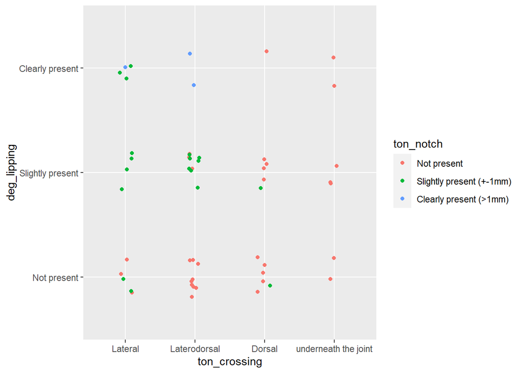

# Regression analyses

… to do after better insight in data

Hypothesis: Combination of location of crossing + amount of degeneration = higher chance of notch? => add an interaction term to a regression model

# Causal inference

Hypothesis: Notch as a result of degeneration? => need causal inference methodology because it’s observational and cross-sectional data. We probably don’t have all confounders of the degeneration -> notch relationship?